# Exercise 1 (25 minutes)

You practice: a full IV workflow on a new instrument — first stage, reduced form, Wald ratio, then 2SLS with controls. When you're done, assist some of the others …

**Acemoglu & Angrist (2000) had an idea.** US federal states required children to have a minimum amount of schooling before they were allowed to work — and *how much* differed across states and changed over time. They argued that the exact year a given state reformed its child-labour law was essentially arbitrary. That gives us an instrument for schooling.

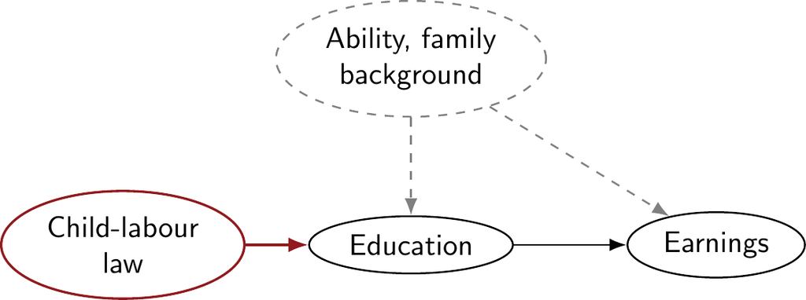

1. Load the data and build the instrument. `cl7`, `cl8` and `cl9` are dummies for living in a state that required 7, 8 or 9 years of schooling. Collapse them into **one continuous** variable, and make state of birth and census year **categorical**.

```r
pacman::p_load(tidyverse, estimatr, ivreg, modelsummary, masteringmetrics)

data("child_labor", package = "masteringmetrics")

child_labor <- child_labor %>%
  mutate(
    # One continuous child-labour-law variable: 7, 8 or 9 required years
    chld_lb_lw = case_when(
      cl7 == 1 ~ 7,
      cl8 == 1 ~ 8,
      cl9 == 1 ~ 9
    ),
    sob  = as_factor(sob),  # US state of birth
    year = as_factor(year)  # Census year
  ) %>%
  drop_na(chld_lb_lw)
```

- Did `pacman::p_load(...)` run without red errors? `ivreg` is new this week — `pacman::p_load()` installs it automatically the first time (this needs internet).
- `data()` can't find `child_labor`? It ships inside **`masteringmetrics`**, which is a GitHub package — see **About & setup** on the course website.
- This data set has ~650,000 rows, so models take a few seconds. That is normal, not a crash.
- Still stuck? Ask in the [t-R-ouble forum](https://absalon.ku.dk/courses/70545/discussion_topics/563046?module_item_id=2037268) on Absalon.
2. **Predict before you compute.** The instrument is "how many years of schooling the law required". Before running anything: which sign do you expect for the **first stage** — the effect of the law on actual years of education?
3. **Estimate the first stage.** Regress `indEduc` on the instrument, controlling for year of birth (`yob`), census year (`year`) and state of birth (`sob`).

`lm_robust(indEduc ~ chld_lb_lw + yob + year + sob, data = child_labor)`

```r
first_stage <- lm_robust(indEduc ~ chld_lb_lw + yob + year + sob,
                         data = child_labor)

modelsummary(list("Years of education" = first_stage),
             coef_map = c("chld_lb_lw" = "Required years of schooling"),
             stars = TRUE, gof_map = c("nobs"), output = "kableExtra")
```

[output not shown]

One extra year of *required* schooling translates into extra years of *actual* education. Call this $\phi$.

4. **Estimate the reduced form.** `lnwkwage` is the log weekly wage. Use the **same** controls.

```r
reduced_form <- lm_robust(lnwkwage ~ chld_lb_lw + yob + year + sob,
                          data = child_labor)

modelsummary(list("log weekly wage" = reduced_form),
             coef_map = c("chld_lb_lw" = "Required years of schooling"),
             stars = TRUE, gof_map = c("nobs"), output = "kableExtra")
```

[output not shown]

5. **Compute the Wald ratio by hand.** Divide, and mind which goes on top.

   $$\lambda = \frac{\rho}{\phi} =
   \;?$$

   Your answer:

```r
phi <- coef(first_stage)["chld_lb_lw"]
rho <- coef(reduced_form)["chld_lb_lw"]

rho / phi
```

[output not shown]

6. **Now do it properly with `ivreg()`.** Write the 2SLS in one line. Remember: the controls must appear on **both** sides of the `|`.

The pattern is `ivreg(outcome ~ treatment + controls | instrument + controls, data = ...)`. Here the treatment is `indEduc` and the instrument is `chld_lb_lw`.

```r
twosls <- ivreg(
  lnwkwage ~ indEduc + yob + year + sob | chld_lb_lw + yob + year + sob,
  data = child_labor
)

modelsummary(list("2SLS" = twosls),
             coef_map = c("indEduc" = "Years of education"),
             stars = TRUE, gof_map = c("nobs"), output = "kableExtra")
```

[output not shown]

7. **Write one sentence** as a `# comment` interpreting the 2SLS estimate in plain language, with units — then compare:

Among men whose schooling was actually changed by child-labour laws, one additional year of education raises weekly wages by about **14%**. Because the estimate uses only the variation in schooling driven by the timing of state law reforms, it is not contaminated by ability or family background — *provided* that timing really was as-if random and affected wages only through schooling. Note this is a **LATE**: it describes compliers — children who would have left school earlier under a laxer law — not the population as a whole.

8. **Bonus, for the fast.** Compare the 2SLS estimate to a naïve OLS of `lnwkwage` on `indEduc` with the same controls. Which is larger, and does that match the ability-bias prediction?

```r
ols <- lm_robust(lnwkwage ~ indEduc + yob + year + sob, data = child_labor)

modelsummary(list("OLS" = ols, "2SLS" = twosls),
             coef_map = c("indEduc" = "Years of education"),
             stars = TRUE, gof_map = c("nobs"), output = "kableExtra")
```

[output not shown]

As in the lecture, the IV estimate comes out **larger** than OLS — the opposite of what simple ability bias predicts. The same three explanations apply: LATE versus ATE (compliers are people pushed through school by law, whose returns may be higher), measurement error in schooling biasing OLS toward zero, and instrument weakness.

9. **Discuss with your neighbour.** The whole design rests on one untestable claim.
   - State the **exclusion restriction** for this instrument in one sentence.
   - Give a concrete reason why the timing of a state's child-labour reform might affect wages through something *other* than schooling.
   - Would adding more control variables settle the question?
- **Exclusion restriction:** the required years of schooling in your state and birth year affect your later wages *only* by changing how much education you actually got.
- Plausible violations: states reform labour law when their **economy is changing** — industrialising states may pass stricter schooling laws *and* offer better-paid jobs later. Reforms may travel with other policies (public spending, health, minimum wages). Families may also move between states.
- **No.** Controls close backdoors through variables you measured; the worry here is that the *instrument itself* has a second route to wages. More controls cannot rule that out — only an argument about how reforms happened can, which is why the paper spends its pages on institutional history rather than on regression tables.